# RESQUE Profile for Felix Schönbrodt

**The “fingerprint” of how research is conducted, when only the best work is submitted.**

| **Overview of analysis**: |  |
| --- | --- |
| Name | Felix Schönbrodt |
| Analysis date | 2026-03-19 |
| Academic age (years since PhD, minus child care etc.) | 15 (PhD: 2010; subtracted years: 1) |
| # of analysed outputs | 10 |
| ORCID | https://orcid.org/0000-0002-8282-3910 |
| RaterType | Applicant |
| AcademicAgeBonus_Explanation | I stayed at home with my two kids and cared for my sick father. |
| CollectorURL | https://resque-framework.github.io/collector-app/ |

Some parts of this profile are purely descriptive. For example, it is summarized the type of participant samples, or whether researchers predominantly work with psychophysiological data or rather focus on questionnaire studies.

Other parts contain an evaluative aspect: For example, research that is reproducible, which allows independent auditing because it provides open data and scripts is, *ceteris paribus*, better than research that does not have these aspects. Research outputs with these objective quality criteria of methodological rigor can gain “bonus points” which are summed across all provided research outputs and contribute to the Rigor Profile Overview.

Methods: Rigor score bias

##### 🧾 Method Details

### Is the rigor score systematically biased against certain fields?

We took care not to systematically disadvantage certain fields or research styles. Generally, the rigor score is a relative score, computed as “percentage of maximal points” (POMP) score across all indicators that are applicable. For any indicator, one can choose the option “not applicable” if an indicator *principally* cannot be attained by a research output. The points of such non-applicable indicators are removed from the maximum points and therefore do not lower the computed relative rigor score.

## Submitted research outputs

The 10 publications had the following methodological type:

| Type of method | # papers |
| --- | --- |
| Computational | 5 |
| Empirical Quantitative | 4 |
| Meta Analysis | 1 |
| Nonempirical | 1 |
| Theoretical | 2 |

### Team science in publications?

10 out of 10 submitted publications could be automatically retrieved with OpenAlex.

| Team category | Frequency | % |
| --- | --- | --- |
| Single authored | 0 | 0% |
| Small team (<= 5 co-authors) | 8 | 80% |
| Large team (6-15 co-authors) | 0 | 0% |
| Big Team (>= 16 co-authors) | 2 | 20% |

## Types of research data

| Data type | # of papers |
| --- | --- |
| Content Data | 3 |
| Behavioral | 1 |
| Other Type | 1 |
| Questionnaire Selfreport | 1 |

### ⤷ Types of behavioral data

| Data type | # of papers |
| --- | --- |
| Performance | 1 |

## Types of samples

Type of population/sample and cultural background for the 3 papers with own new data collection (“Other” excluded):

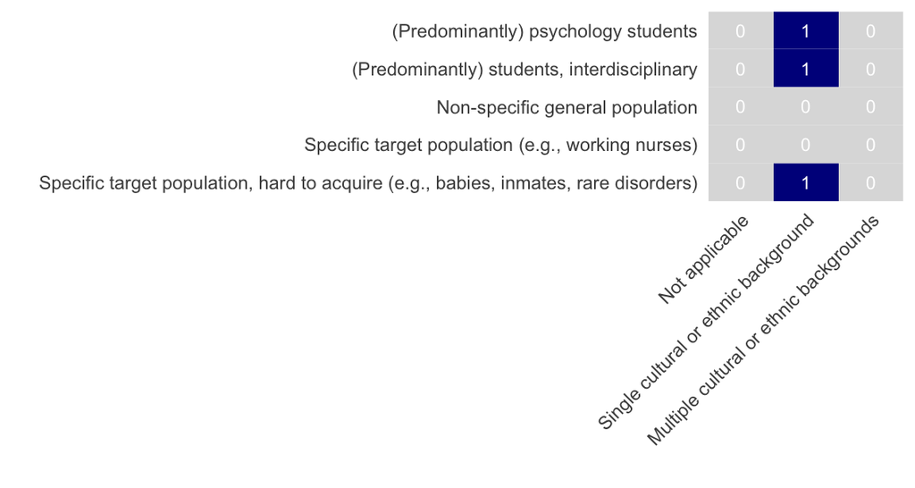

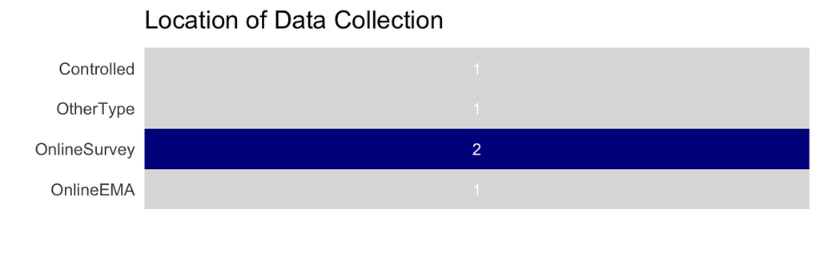

**Rare samples used in studies:**

- Inmates
  - *Sample Size*: not provided

## Types of Research Designs

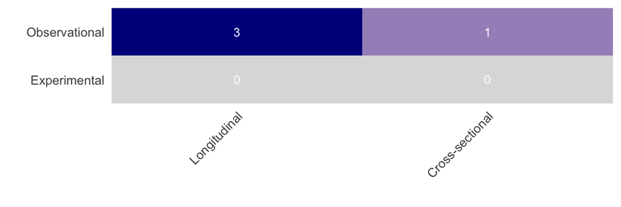

# Contributorship profile (CRediT roles)

Based on 10 submitted publications, this is the self-reported contributorship profile:

**Full CRediT profile**

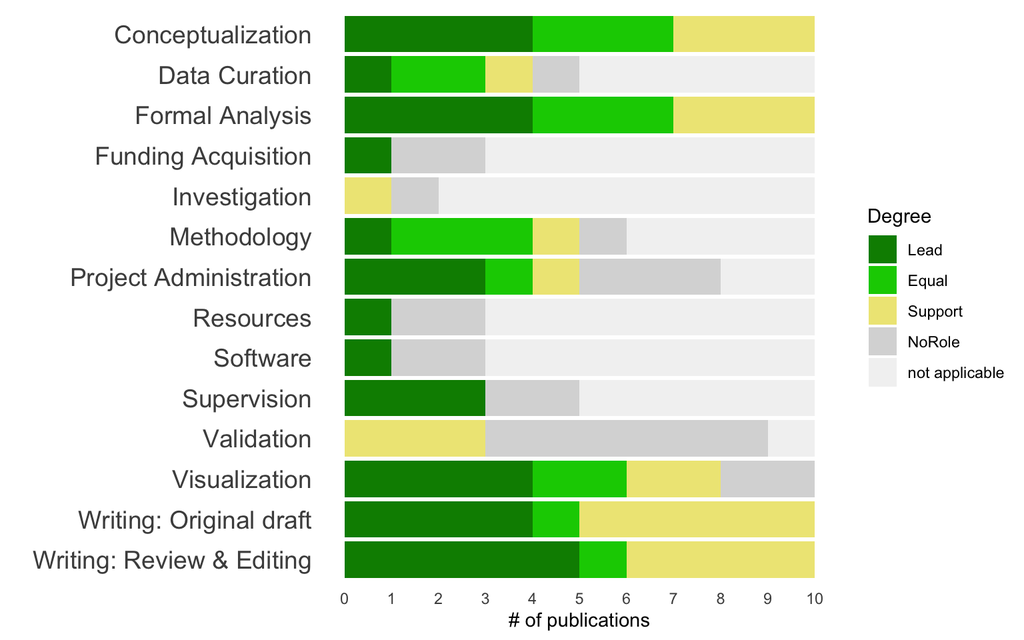

**Compact CRediT profile**

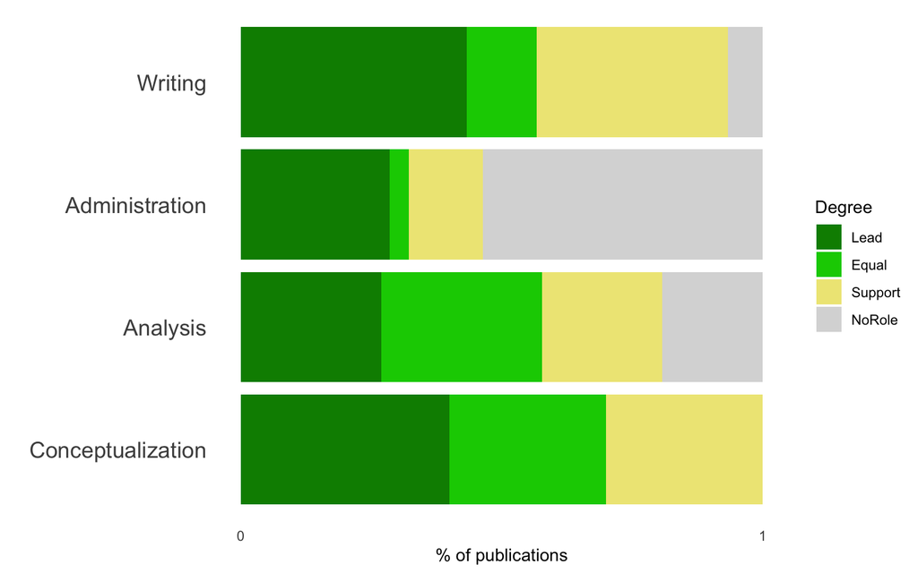

# Indicators of Research Transparency and Reproducibility

Methods: Computation of the Relative Rigor Score

##### 🧾 Method Details

### Computation of the Relative Rigor Score

The relative rigor score (RRS) is computed as a percentage of maximal points (POMP) score of multiple indicators. The indicators are grouped into four categories: Open Data, Preregistration, Reproducible Code & Verification, and Open Materials. Indicators that are flagged as “not applicable” are removed from the maximum points and therefore do not lower the RRS.

The following charts are based on 9 scoreable publications.

**What is a “good” Relative Rigor Score?**

The RESQUE indicators cover current best practices, which often are not yet used broadly. Therefore the scores might look meager, even for very good papers. Tentative norm values for the overall rigor score, based on some first evaluation studies are:

- 10-20% can be considered average
- 30% is very good
- >40% is excellent.

[output not shown]

How to read the small charts

##### 🧾 Method Details

### How to read the small charts

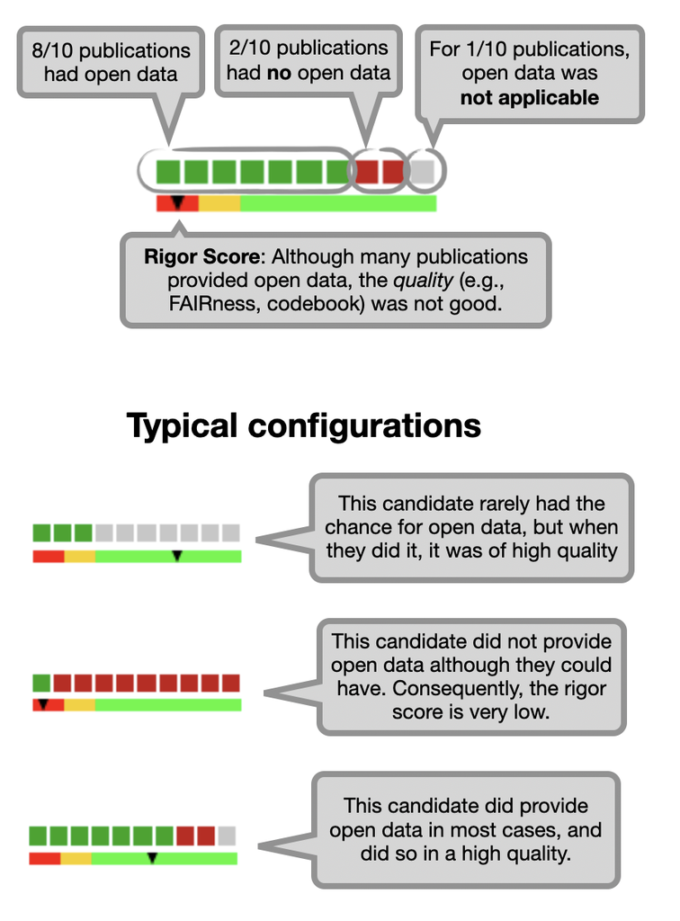

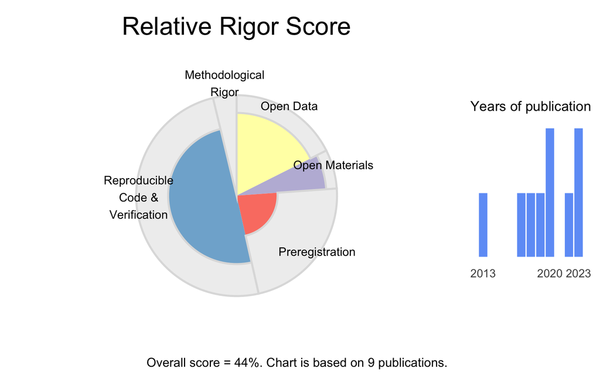

How to read the radar chart

##### 🧾 Method Details

### How to read the radar chart

The general philosophy of RESQUE is: It doesn’t matter so much what kind of research you do - but when you do it, you should do it in a high quality. The radar chart with the **Relative Rigor Score** helps you to see how many quality indicators have been fulfilled in multiple areas of methodological rigor.

- The **width** of each sector corresponds to the **maximal number of rigor points** one could gain. If many indicators are flagged as “not applicable”, then the maximal points get reduced and the sector gets more narrow.
- The **colored part** of each sector shows the **achieved rigor points**. An entirely grey sector indicates that no rigor points could be awarded at all.
- The quality indicators measure both the *presence* of a practice (e.g., is Open Data available?) and the *quality* of the practice (e.g., is does it have a codebook? Does have a persistent identifier?). Hence, even if the pie charts in the table above show the presence, a lack of quality indicators can lead to a low rigor score.

# Scientific impact

[BIP! Scholar](https://bip.imsi.athenarc.gr/site/home) (a non-commercial open-source service to facilitate fair researcher assessment) provides **five impact classes** based on norm values:

| 🚀 Top 0.01% | ️🌟 Top 0.1% | ️✨ Top 1% | Top 10% | Average (Bottom 90%) |
| --- | --- | --- | --- | --- |

Methods: Popularity metric & CRediT involvement

##### 🧾 Method details

### Computation of the Popularity metric

This indicator reflects impact/attention of an article in the research community at large. It is based on *AttRank*, a variation of PageRank (known from the Google search algorithm) that accounts for the temporal evolution of the citation network. By that, it alleviates the bias against younger publications, which have not had the chance to accumulate a lot of citations. It models a researcher’s preference to read papers which received a lot of attention recently. It was evaluated (and vetted) in its performance to predict the ranking of papers concerning their *future impact* (i.e., citations). For more details, see [BIP! glossary](https://bip.imsi.athenarc.gr/site/indicators) and the references therein.

### CRediT Levels of involvement

We categorized papers into levels of involvement, based on the degrees of contributorship:

| Involvement.Level | Definition | Publications |
| --- | --- | --- |
| Very High | (>=3 roles as *lead*) OR (>= 5 roles as (*lead* OR *equal*)) | 5 |
| High | (1-2 roles as *lead*) OR (3-4 roles as *equal*) | 4 |
| Medium | (1-2 roles as *equal*) OR (>= 5 roles as *support*) | 1 |
| Low | All other combinations | 0 |

From 10 submitted papers of Felix Schönbrodt, 10 were in the top 10% popularity class of all papers or better.

## Highly popular publications

| Title | 3 year citation count | Overall citation count | FNCS | Popularity | Rigor Score | Candidates' CRediT involvement | Candidates' CRediT main roles |
| --- | --- | --- | --- | --- | --- | --- | --- |
| 🚀[Schönbrodt & Perugini (2013): At what sample size do correlations stabilize?](https://doi.org/10.1016/j.jrp.2013.05.009) | 75 | 1666 | 88.6 | Top 0.01% | 79% | Very High | **Lead:** Conceptualization, Formal Analysis, Methodology, Project Administration, Visualization, Writing: Original draft, Writing: Review & Editing |
| ️🌟[Nosek et al. (2022): Replicability, Robustness, and Reproducibility in Psychological Science](https://doi.org/10.1146/annurev-psych-020821-114157) | 327 | 479 | 93.5 | Top 0.1% | 19% | Medium | **Equal:** Data Curation, Formal Analysis |
| ️🌟[Schönbrodt & Wagenmakers (2017): Bayes factor design analysis: Planning for compelling evidence](https://doi.org/10.3758/s13423-017-1230-y) | 70 | 477 | 48.6 | Top 0.1% | 48% | Very High | **Lead:** Conceptualization, Formal Analysis, Visualization, Writing: Original draft, Writing: Review & Editing **Equal:** Methodology |
| ️🌟[Carter et al. (2019): Correcting for Bias in Psychology: A Comparison of Meta-Analytic Methods](https://doi.org/10.1177/2515245919847196) | 103 | 364 | 47.8 | Top 0.1% | 57% | High | **Lead:** Software **Equal:** Conceptualization, Formal Analysis, Methodology, Project Administration, Visualization, Writing: Original draft, Writing: Review & Editing |
| ️✨[Stefan & Schönbrodt (2023): Big little lies: a compendium and simulation of *p* -hacking strategies](https://doi.org/10.1098/rsos.220346) | 77 | 77 | 42.8 | Top 1% | 28% | High | **Lead:** Supervision **Equal:** Conceptualization, Methodology |
| ️✨[Schönbrodt et al. (2018): Testing Similarity Effects with Dyadic Response Surface Analysis](https://doi.org/10.1002/per.2169) | 30 | 139 | 12.2 | Top 1% | - | Very High | **Lead:** Conceptualization, Formal Analysis, Project Administration, Visualization, Writing: Original draft, Writing: Review & Editing |
| [Etzler et al. (2023): Machine Learning and Risk Assessment: Random Forest Does Not Outperform Logistic Regression in the Prediction of Sexual Recidivism](https://doi.org/10.1177/10731911231164624) | 8 | 8 | 4.7 | Top 10% | 23% | High | **Equal:** Data Curation, Formal Analysis, Visualization |
| [Schönbrodt et al. (2020): Measuring Implicit Motives with the Picture Story Exercise (PSE): Databases of Expert-Coded German Stories, Pictures, and Updated Picture Norms](https://doi.org/10.1080/0022… | 19 | 26 | 4.0 | Top 10% | 44% | Very High | **Lead:** Conceptualization, Data Curation, Formal Analysis, Project Administration, Visualization, Writing: Original draft, Writing: Review & Editing |
| [Woll & Schönbrodt (2020): A Series of Meta-Analytic Tests of the Efficacy of Long-Term Psychoanalytic Psychotherapy](https://doi.org/10.1027/1016-9040/a000385) | 9 | 21 | 2.5 | Top 10% | 47% | High | **Lead:** Supervision |
| [Zygar et al. (2018): From Motive Dispositions to States to Outcomes: An Intensive Experience Sampling Study on Communal Motivational Dynamics in Couples](https://doi.org/10.1002/per.2145) | 14 | 24 | 2.4 | Top 10% | 53% | Very High | **Lead:** Funding Acquisition, Resources, Supervision, Writing: Review & Editing **Equal:** Conceptualization |

Note:  
FNCS = Field- and age-normalized citation score: This is the factor by which a publication is cited more often than other publications from the same field and the same publication year. A value of 2, for example, indicates that the publication got cited twice as much as comparable publications.

## Publications without citation metrics & average popular publications

For very new publications, no citation metrics can be computed.

No publications submitted without citation metrics or average popularity class.

# Internationality and Interdisciplinarity

**NoteMethods: Computation of Internationality and Interdisciplinarity**

The analysis is only based on the submitted publications (not the entire publication list) of the applicant. Publication and co-author data is retrieved from the OpenAlex data base. Note that preprints are not indexed by OpenAlex and therefore do not contribute to this analysis.

- *Internationality*: All co-authors are retrieved from OpenAlex with their current affiliation. The index is measured by Pielou’s Evenness Index (Pielou 1966) of the country codes of all co-authors. It considers the 10 most frequent country codes.
- *Interdisciplinarity* is measured by the Evenness Index of the fields (as classified by OpenAlex) of the publications. It considers the 6 most frequent fields.

The evenness indexes are normalized to a scale from 0 (no diversity, everything is one category) to 1 (maximum diversity, all categories are equally represented). It is computed as a normalized Shannon entropy.

**Internationality**

**Interdisciplinarity**

Only within country co-authors

Broad coauthor network from many countries

Single discipline

Many disciplines

49 unique identifiable co-authors:

- 49% from 7 international countries
- 51% from the same country

3 primary fields:

- Psychology (8)
- Computer Science (1)
- Decision Sciences (1)

| Co-authors' Country Code | # of Co-authors |
| --- | --- |
| DE | 25 |
| US | 10 |
| NL | 6 |
| AT | 2 |
| AU | 2 |
| CH | 2 |
| IT | 1 |
| SE | 1 |

The main subfields are (multiple categories per paper are possible):

| Subfield | # of papers |
| --- | --- |
| Experimental and Cognitive Psychology | 6 |
| Clinical Psychology | 5 |
| Applied Psychology | 3 |
| Social Psychology | 3 |
| Information Systems and Management | 2 |
| Sociology and Political Science | 2 |

# “Not applicable” justifications

Why committees should check the “not applicable” justifications

##### ⚠️ Important note for committees

### Gaming RESQUE: Why committees should check the “not applicable” justifications

Choosing “not applicable” indicates that an indicator *principally* cannot be attained by a research output. To avoid bias against certain research fields, the points of such non-applicable indicators are removed from the maximum points and therefore do not lower the computed relative rigor score.

**However, in order to prevent gaming of this scheme, any “not applicable” claim needs to be justified.** Applicants trying to maximize their rigor score will overuse the “not applicable” option, without providing a sound justification.

How to deal with unsound justifications?

*A (tedious) manual way of adjusting:* With no or insufficent justification the indicator should be set to “not available” (=0 points) and then the maximum points are not adjusted. This correction currently needs to be done manually in the json file of the applicant. You should also record any changes in a changelog to make transparent what has been changed from the applicant’s own self-report.

*“Intuitive” adjustment:* Previous committees who noticed an excessive usage of the “not applicable” option factored that holistically into the assessment of the candidate, and used that information to ask specific questions in the interview stage.

These are all claims of non-applicability from this applicant:

### P_Preregistration

| Title | Year | Why not applicable? |
| --- | --- | --- |
| [Stefan & Schönbrodt (2023): Big little lies: a compendium and simulation of <i>p</i> -hacking strategies](https://doi.org/10.1098/rsos.220346) | 2023 | Purely exploratory |
| [Carter et al. (2019): Correcting for Bias in Psychology: A Comparison of Meta-Analytic Methods](https://doi.org/10.1177/2515245919847196) | 2019 | Exploratory |
| [Schönbrodt & Wagenmakers (2017): Bayes factor design analysis: Planning for compelling evidence](https://doi.org/10.3758/s13423-017-1230-y) | 2017 | exploratory/method development |
| [Schönbrodt & Perugini (2013): At what sample size do correlations stabilize?](https://doi.org/10.1016/j.jrp.2013.05.009) | 2013 | Purely Exploratory |

### P_OpenMaterials

| Title | Year | Why not applicable? |
| --- | --- | --- |
| [Stefan & Schönbrodt (2023): Big little lies: a compendium and simulation of <i>p</i> -hacking strategies](https://doi.org/10.1098/rsos.220346) | 2023 | Everything is contained in the source code. |
| [Nosek et al. (2022): Replicability, Robustness, and Reproducibility in Psychological Science](https://doi.org/10.1146/annurev-psych-020821-114157) | 2022 | No material was used, other than the data itself. |
| [Schönbrodt & Wagenmakers (2017): Bayes factor design analysis: Planning for compelling evidence](https://doi.org/10.3758/s13423-017-1230-y) | 2017 | The scripts contain everything |
| [Schönbrodt & Perugini (2013): At what sample size do correlations stabilize?](https://doi.org/10.1016/j.jrp.2013.05.009) | 2013 | The scripts contain everything |

### P_Sample_RepresentativenessRelevance

| Title | Year | Why not applicable? |
| --- | --- | --- |
| [Nosek et al. (2022): Replicability, Robustness, and Reproducibility in Psychological Science](https://doi.org/10.1146/annurev-psych-020821-114157) | 2022 | no human data |

### P_Data_Open

| Title | Year | Why not applicable? |
| --- | --- | --- |
| [Etzler et al. (2023): Machine Learning and Risk Assessment: Random Forest Does Not Outperform Logistic Regression in the Prediction of Sexual Recidivism](https://doi.org/10.1177/10731911231164624) | 2023 | (automatically added: For reused data sets of other researchers and for ‘no data’, we automatically set P_Data_Open to ‘notApplicable’). |
| [Nosek et al. (2022): Replicability, Robustness, and Reproducibility in Psychological Science](https://doi.org/10.1146/annurev-psych-020821-114157) | 2022 | Proprietary data, could not share |

# “Not suitable” justifications

These were the justification, why papers have been flagged as “generally not suitable for the RESQUE scheme”. These papers have been excluded from the rigor score computation, but not from the impact table.

**The applicant had no claims of non-suitability or gave no justification.**

Appendix: Preprocessing notes

##### Preprocessing Notes

- For 1 publication(s) with P_Data_Source = ‘Reuse of someone else’s existing data set’ or P_Data = ‘No’, P_Data_Open has been set to ‘notApplicable’ and a justification has been added.)
- 1 publication(s) were removed from the rigor score computations because no indicators were provided.

*RESQUER package version: 0.10.2*